# Practical Machine Learning Assignment

# Synopsis

We will try to predict how well an exercise has been performed, using data from wearable fitness devices.

# Results

## Preparation

```r
library(ggplot2)
library(caret)
library(dplyr)
raw_training <- read.csv('pml-training.csv')
testing <- read.csv('pml-testing.csv')
training <- raw_training[,-(1:7)]
testing <- testing[,-(1:7)]
training$classe <- as.factor(training$classe)
```

Looking at the data we see that the first few variables are metadata, hence we removed them. Also some of the variables have not been loaded as numerics properly. We remedy this

```r
y <- training$classe
training <- training[,-ncol(training)]
training <- data.frame(apply(training,2,as.numeric),classe=y)
testing <- data.frame(apply(testing,2,as.numeric))
```

Next we check if some columns are basically empty and remove them

```r
basically_empty <- function(df){
    res <- c()
    for (k in 1:ncol(df))
        if (class(df[[k]])=="numeric"){
            if (sum(df[[k]],na.rm=TRUE) == 0){
                res <- c(res,k)
            }
        }
    res
}
to_remove <- basically_empty(training)
training <- training[,-to_remove]
testing <- testing[,-to_remove]
```

## Training models

```r
set.seed(123)
rfAll <-
    train(data=training, classe~., method="rf", na.action=na.omit)
```

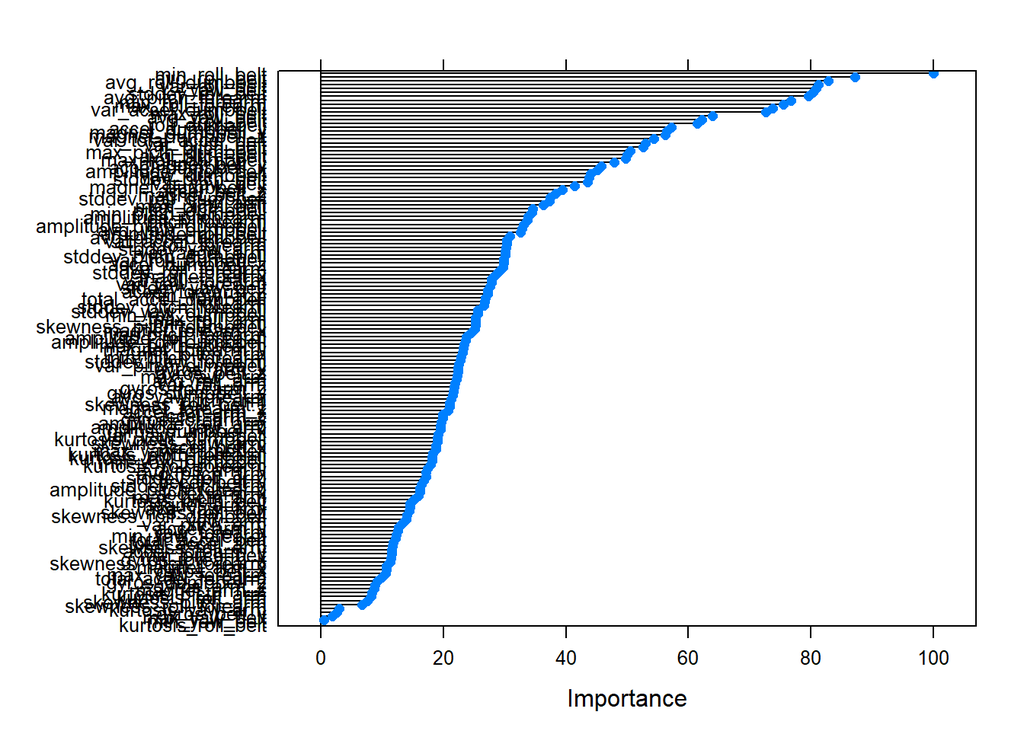

```r
plot(varImp(rfAll))
```

Even though one cannot make out the names of the variables from eyeballing it, it seems that importance seems to drop drastically somewhere around 40

So let us extract the columns with an importance over 35.

```r
important_variables <- names(training[,-144])[varImp(rfAll)$importance>35]
length(important_variables) # it is a coincidence that it is also 35 :D
```

```
## [1] 35
```

Checking the testing set we see that various columns of important variables are completely empty. We therefore remove these variables

```r
missing_in_testing <- names(testing)[basically_empty(testing)]
remaining <- setdiff(important_variables,missing_in_testing)
length(remaining)
```

```
## [1] 13
```

Before we train our final model we use the mean to impute (i.e. fill the missing data).

```r
remTest <- subset(testing,select=c(remaining,"problem_id"))
remTrain <- subset(training,select=c(remaining,"classe"))


for (k in 1:ncol(remTrain[,-ncol(remTrain)])){
    m <- mean(remTrain[[k]],na.rm=TRUE)
    remTrain[[k]][is.na(remTrain[[k]])] <- m
}
```

Now we train a random forest and a boosting classifier. We chose these two methods because the are very general and very accurate. I tried to train the models on the whole dataset but it took multiple hours, so I am taking the liberty of using a smaller subset.

```r
set.seed(456)
N=5000
rows_for_rf <- sample(1:nrow(remTrain),N)
train_for_rf <- remTrain[rows_for_rf,]
rows_for_gbm <- sample(setdiff(1:nrow(remTrain),rows_for_rf),N)
train_for_gbm <- remTrain[rows_for_gbm,]
rows_for_validation <- setdiff(setdiff(1:nrow(remTrain),rows_for_rf),rows_for_gbm)
# Note that we train the rf and gbm on different rows
# In particular the combined model has seen 10000 rows in total
# And that this leaves us with a big validation set
rfImp <-
    train(data=train_for_rf, classe~., method="rf")
gbmImp <-
    train(data=train_for_gbm, classe~., method="gbm", verbose=FALSE)
```

```r
set.seed(789)
# Predict on the whole set except for the validation
# Then train the combined model
rfPred <- predict(rfImp, newdata=training[-rows_for_validation,])
gbmPred <- predict(gbmImp, newdata=training[-rows_for_validation,])
temp <- training[-rows_for_validation,]$classe
preds <- data.frame(rf=rfPred,gbm=gbmPred,classe=temp)
combinedFit <- train(data=preds,classe~rf+gbm,method="rf")
```

Next we test the model on some unseen data.

```r
validate <- remTrain[rows_for_validation,]
rfValPred <- predict(rfImp,newdata=validate)
gbmValPred <- predict(gbmImp,newdata=validate)
valPreds <- data.frame(rf=rfValPred,gbm=gbmValPred)
combinedPred <- predict(combinedFit,newdata=valPreds)
confusionMatrix(combinedPred,validate$classe)
```

```
## Confusion Matrix and Statistics
##
##           Reference
## Prediction    A    B    C    D    E
##          A 2676  114   46   20   16
##          B   35 1665   58    8   18
##          C   18   61 1516  128   11
##          D   20   28   41 1455   12
##          E    2    0    0    8 1666
##
## Overall Statistics
##
##                Accuracy : 0.9331
##                  95% CI : (0.9279, 0.938)
##     No Information Rate : 0.2859
##     P-Value [Acc > NIR] : < 2.2e-16
##
##                   Kappa : 0.9152
##
##  Mcnemar's Test P-Value : < 2.2e-16
##
## Statistics by Class:
##
##                      Class: A Class: B Class: C Class: D Class: E
## Sensitivity            0.9727   0.8913   0.9127   0.8987   0.9669
## Specificity            0.9715   0.9847   0.9726   0.9874   0.9987
## Pos Pred Value         0.9318   0.9333   0.8743   0.9351   0.9940
## Neg Pred Value         0.9889   0.9741   0.9816   0.9797   0.9928
## Prevalence             0.2859   0.1941   0.1726   0.1683   0.1791
## Detection Rate         0.2781   0.1730   0.1576   0.1512   0.1731
## Detection Prevalence   0.2985   0.1854   0.1802   0.1617   0.1742
## Balanced Accuracy      0.9721   0.9380   0.9427   0.9430   0.9828
```

We see that we have above 90% out of sample accuracy, even by training on a subset.

## Predict on the testing data

```r
rfTestPred <- predict(rfImp,newdata=remTest)
gbmTestPred <- predict(gbmImp,newdata=remTest)
predsTest <- data.frame(rf=rfTestPred,gbm=gbmTestPred)
combinedTestPred <- predict(combinedFit,newdata=predsTest)
combinedPred
```

[output not shown]

[output cut: 247 more lines]